# Homework 5

Diana Rueda

11/12/2021

# Question 2

#### (a) Plot the sample acf and pacf of 𝑥𝑡 and determine an appropriate ARMA model for the data

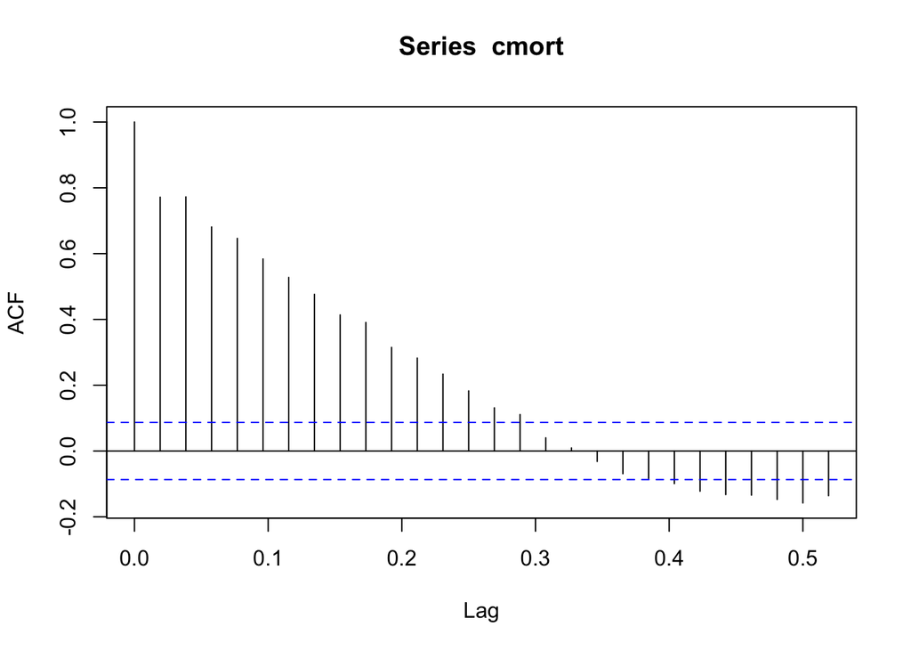

```r
library(astsa)
acf(cmort)
```

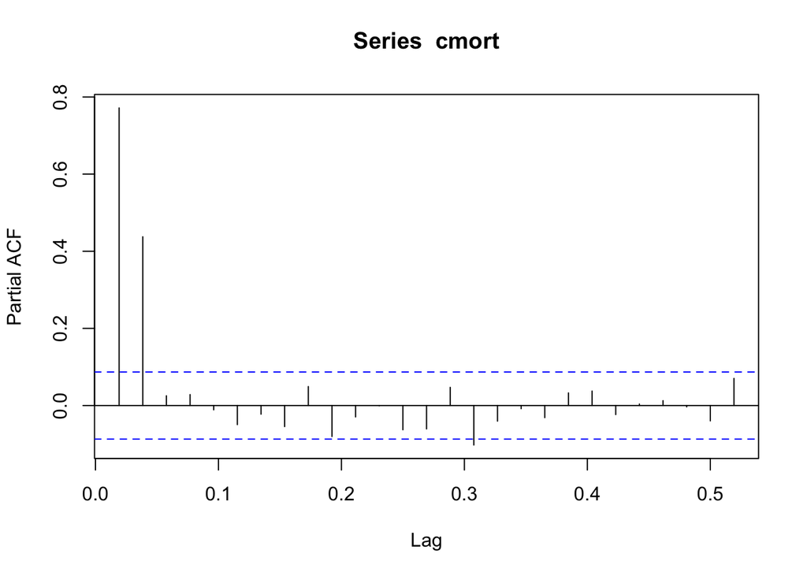

```r
acf(cmort, type = 'partial')
```

Since the ACF tails off and the PACF cuts off after lag 2 we can suggest it is an AR(2) model.

#### (b) Fit the model to the data by using the function “sarima()” in R package “astsa” and then determine the fitted model.

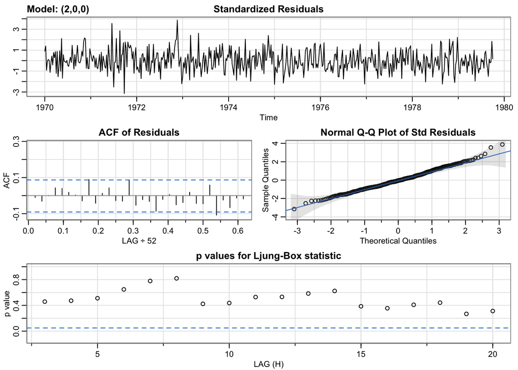

```r
cmort_fit = sarima(cmort, p = 2, d = 0, q = 0)
```

```r
cmort_fit
```

```
## $fit
##
## Call:
## arima(x = xdata, order = c(p, d, q), seasonal = list(order = c(P, D, Q), period = S),
##     xreg = xmean, include.mean = FALSE, transform.pars = trans, fixed = fixed,
##     optim.control = list(trace = trc, REPORT = 1, reltol = tol))
##
## Coefficients:
##          ar1     ar2    xmean
##       0.4301  0.4424  88.8538
## s.e.  0.0397  0.0398   1.9407
##
## sigma^2 estimated as 32.37:  log likelihood = -1604.71,  aic = 3217.43
##
## $degrees_of_freedom
## [1] 505
##
## $ttable
##       Estimate     SE t.value p.value
## ar1     0.4301 0.0397 10.8404       0
## ar2     0.4424 0.0398 11.1245       0
## xmean  88.8538 1.9407 45.7839       0
##
## $AIC
## [1] 6.333521
##
## $AICc
## [1] 6.333615
##
## $BIC
## [1] 6.366832
```

We need to fit X_t - mu = phi1 (X_t-1 - mu) + phi2 (X_t-2 - mu) + W_t. Where phi1 = 0.4301, phi2 = 0.4424 and mu = 88.8538

#### (c) Use the fitted model to find the 1,…,4 -step-ahead prediction of the series, i.e. 𝑥𝑛𝑛+𝑘,𝑘=1,2,3,4 , and compare your computation with the one obtained by applying the R function “sarima.for()”. Please show the details of your computations.

```r
n = length(cmort)

xn1 = sum(cmort_fit$fit$coef * c(cmort[n] - cmort_fit$fit$coef[3], cmort[n-1] - cmort_fit$fit$coef[3], 1))

xn2 = sum(cmort_fit$fit$coef * c(xn1 - cmort_fit$fit$coef[3], cmort[n] - cmort_fit$fit$coef[3], 1))

xn3 = sum(cmort_fit$fit$coef * c(xn2 - cmort_fit$fit$coef[3], xn1 - cmort_fit$fit$coef[3], 1))

xn4 = sum(cmort_fit$fit$coef * c(xn3 - cmort_fit$fit$coef[3], xn2 - cmort_fit$fit$coef[3], 1))
```

The 1,2,3,4 step-ahead predictions are as follow:

```r
c(xn1, xn2, xn3, xn4)
```

```
## [1] 87.66207 86.85311 87.46615 87.37190
```

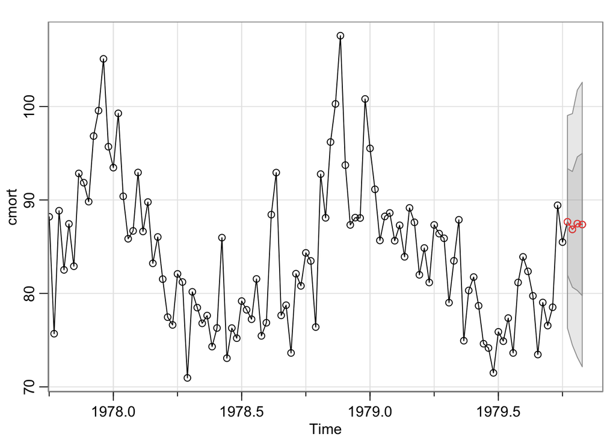

```r
cmort_sarima = sarima.for(cmort, n.ahead=4, p=2, d=0, q=0)
```

```r
cmort_sarima
```

```
## $pred
## Time Series:
## Start = c(1979, 41)
## End = c(1979, 44)
## Frequency = 52
## [1] 87.66207 86.85311 87.46615 87.37190
##
## $se
## Time Series:
## Start = c(1979, 41)
## End = c(1979, 44)
## Frequency = 52
## [1] 5.689543 6.193387 7.148343 7.612531
```

As we can see the predictions from the model are the same as the results from sarima.for

#### (d) Compute the MSPE (Mean Square Prediction Error) of forecasts you obtained in part (c) (, i.e. 𝑃̃𝑛+1,𝑃̃𝑛+2,𝑃̃𝑛+3, and 𝑃̃𝑛+4) and compare it with the one produced by “sarima.for()”. Please show the details of you computations

```r
coef = ARMAtoMA(ar = c(cmort_fit$fit$coef[1], cmort_fit$fit$coef[2]), ma=0, 50)

pn1 = cmort_fit$fit$sigma2 * (1)

pn2 = cmort_fit$fit$sigma2 * (1 + coef[1]^2)

pn3 = cmort_fit$fit$sigma2 * (1 + sum(coef[1:2]^2))
```

[output not shown]

The manually computed values are:

```r
c(pn1, pn2, pn3)
```

```
## [1] 32.37090 38.35804 51.09881
```

The values obtained from the sarima.for question are:

```r
cmort_sarima$se^2
```

```
## Time Series:
## Start = c(1979, 41)
## End = c(1979, 44)
## Frequency = 52
## [1] 32.37090 38.35804 51.09881 57.95062
```

As we can see they are equal.